```python
import pandas as pd
import numpy as np
from matplotlib import pyplot as plt
from scipy.stats import norm, lognorm, probplot, linregress
```

# Problem 2

## 0. Merge csvs

```python
clim = pd.read_csv('camels_clim.csv', sep=';')
geol = pd.read_csv('camels_geol.csv', sep=';')
hydro = pd.read_csv('camels_hydro.csv', sep=';')
name = pd.read_csv('camels_name.csv', sep=';')
soil = pd.read_csv('camels_soil.csv', sep=';')
topo = pd.read_csv('camels_topo.csv', sep=';')
vege = pd.read_csv('camels_vege.csv', sep=';')

camels = pd.merge(name, clim, on='gauge_id')
camels = pd.merge(camels, geol, on='gauge_id')
camels = pd.merge(camels, hydro, on='gauge_id')
camels = pd.merge(camels, soil, on='gauge_id')
camels = pd.merge(camels, topo, on='gauge_id')
camels = pd.merge(camels, vege, on='gauge_id')

camels = camels.dropna()

meanq = camels['q_mean']
```

## i. Does q_mean follow normal or lognormal distribution?

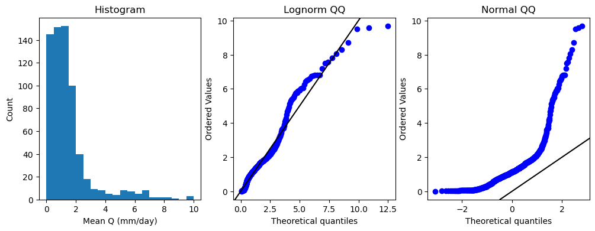

```python
fig, (axhist, axqqln, axqqnorm) = plt.subplots(ncols=3, figsize=(12, 4))

axhist.hist(hydro['q_mean'], bins=np.linspace(0, 10, 21))
axhist.set_xlabel('Mean Q (mm/day)')
axhist.set_ylabel('Count')
axhist.set_title('Histogram')

probplot(hydro['q_mean'], dist=lognorm, sparams=(0.9,), plot=axqqln)
axqqln.set_title('Lognorm QQ')
axqqln.axline((0, 0), slope=1, c='black')

probplot(hydro['q_mean'], dist=norm, plot=axqqnorm)
axqqnorm.set_title('Normal QQ')
axqqnorm.axline((0, 0), slope=1, c='black')
```

The distribution is more similar to a lognormal than it is to a normal.

## ii. eCDF of q_mean

```
25 percentile = 0.48766079597845147
50 percentile = 1.00495932679689
75 percentile = 1.72115186189958
```

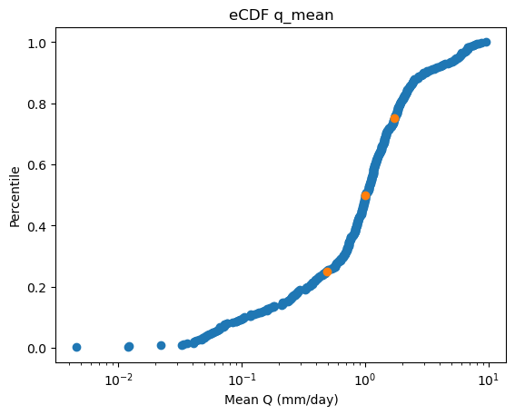

```python
ranks = meanq.rank(pct=True)

fig, ax = plt.subplots()
ax.scatter(meanq, ranks)
ax.set_xscale('log')
ax.set_xlabel('Mean Q (mm/day)')
ax.set_ylabel('Percentile')
ax.set_title('eCDF q_mean')

n25 = np.percentile(meanq, 25)
n50 = np.percentile(meanq, 50)
n75 = np.percentile(meanq, 75)

ax.scatter([n25, n50, n75], [0.25, 0.50, 0.75])
print(f'25 percentile = {n25}')
print(f'50 percentile = {n50}')
print(f'75 percentile = {n75}')
```

## iii. Outliers in q_mean

```python
logQ = np.log10(meanq)

median = np.median(logQ)
q1 = np.percentile(logQ, 25)
q3 = np.percentile(logQ, 75)
iqr = q3 - q1

upper_whisker = q3 + iqr
lower_whisker = q1 - iqr

upper_outliers = logQ.loc[(logQ > upper_whisker)]
lower_outliers = logQ.loc[(logQ < lower_whisker)]

upper_outlier_gage_names = camels.loc[upper_outliers.index, 'gauge_name']
lower_outlier_gage_names = camels.loc[lower_outliers.index, 'gauge_name']


print('Outliers above normal range')
print(' ')
for ogn in upper_outlier_gage_names:
    print(ogn)
print('----------------------------------')
print('Outliers below normal range')
print(' ')
for ogn in lower_outlier_gage_names:
    print(ogn)
```

```
Outliers above normal range

NASELLE RIVER NEAR NASELLE, WA
SATSOP RIVER NEAR SATSOP, WA
CALAWAH RIVER NEAR FORKS, WA
NF SKOKOMISH R BL STAIRCASE RPDS NR HOODSPORT, WA
REX RIVER NEAR CEDAR FALLS, WA
MIDDLE FORK SNOQUALMIE RIVER NEAR TANNER, WA
SF SNOQUALMIE RIVER AT EDGEWICK, WA
SF SNOQUALMIE RIVER AT NORTH BEND, WA
NORTH FORK TOLT RIVER NEAR CARNATION, WA
SOUTH FORK TOLT RIVER NEAR INDEX, WA
NF STILLAGUAMISH RIVER NEAR ARLINGTON, WA
NEWHALEM CREEK NEAR NEWHALEM, WA
SAUK RIVER AB WHITECHUCK RIVER NEAR DARRINGTON, WA
BLAZED ALDER CREEK NEAR RHODODENDRON, OREG.
NORTH FORK BULL RUN RIVER NEAR MULTNOMAH FALLS, OR
SOUTH FORK BULL RUN RIVER NEAR BULL RUN, OR
SILETZ RIVER AT SILETZ, OR
CHETCO RIVER NEAR BROOKINGS, OR
----------------------------------
Outliers below normal range

SHEYENNE RIVER NR WARWICK, ND
SHEYENNE RIVER NR COOPERSTOWN, ND
BALDHILL CREEK NR DAZEY, ND
WINTERING RIVER NR KARLSRUHE, ND
WILLOW CREEK NR WILLOW CITY, ND
BEAR DEN CREEK NR MANDAREE, ND
KNIFE RIVER AT MANNING, ND
KNIFE RIVER NR GOLDEN VALLEY, ND
GREEN RIVER NR NEW HRADEC, ND
CANNONBALL RIVER AT REGENT, ND
CEDAR CREEK NR HAYNES, ND
CEDAR CREEK NR RALEIGH, ND
CANNONBALL RIVER AT BREIEN, ND
MOREAU R NEAR WHITEHORSE SD
BATTLE CR AT HERMOSA SD
SOUTH FORK BAD R NEAR COTTONWOOD,SD
WHITE R NEAR KADOKA SD
```

[output cut: 26 more lines]

```
GILA RIVER NEAR GILA, NM
BONITA CREEK NEAR MORENCI, AZ.
SANTA CRUZ RIVER NEAR LOCHIEL, AZ.
PANTANO WASH NEAR VAIL, AZ.
CIBECUE CREEK NEAR CHYSOTILE, AZ.
CHERRY CREEK NEAR GLOBE, AZ.
CAVE CREEK BLW COTTONWOOD CR NEAR CAVE CREEK, AZ.
VERNON CREEK NEAR VERNON, UT
PALM CYN C NR PALM SPRINGS CA
DEEP C NR PALM DESERT CA
SAN LORENZO C BL BITTERWATER C NR KING CITY CA
LOS GATOS C AB NUNEZ CYN NR COALINGA CA
CANTUA C NR CANTUA CREEK CA
ORESTIMBA C NR NEWMAN CA
DEL PUERTO C NR PATTERSON CA
```

The outliers above the normal range are concentrated in WA and OR. They have exceptionally high mean discharge because of the rain shadow created by the Cascades. The outliers below the normal range are concentrated in the Plains states (ND, SD, NE, KS, OK, TX) and Southwestern desert states (CO, CA, UT, AZ, NM, NV).

## iv. q_mean vs. p_mean

```
(-0.3, 9.383729979466121)
```

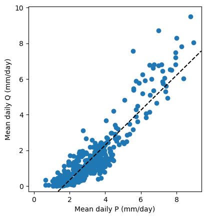

```python
fig, ax = plt.subplots()
ax.scatter(camels['p_mean'], camels['q_mean'])
ax.set_xlabel('Mean daily P (mm/day)')
ax.set_ylabel('Mean daily Q (mm/day)')
ax.set_aspect('equal')

lr = linregress(camels['p_mean'], camels['q_mean'])
ax.axline(xy1=(0, lr[1]), slope=lr[0], c='black', linestyle='--')
ax.set_ylim(-0.30)
ax.set_xlim(-0.30)
```

The relationship between Q and P is approximately linear or very slightly concave up. It appears to depart from the regression line at the low end because at Q = 0, P =~ 1.5, and both variables are bounded by 0. It departs from the regression line at the high end for a less easily discernible reason.

## v. Boxplot for HUCs 1, 4, 15

```python
camels
```

|  | gauge_id | huc_02 | gauge_name | p_mean | pet_mean | p_seasonality | frac_snow | aridity | high_prec_freq | high_prec_dur | ... | area_geospa_fabric | frac_forest | lai_max | lai_diff | gvf_max | gvf_diff | dom_land_cover_frac | dom_land_cover | root_depth_50 | root_depth_99 |
| --- | --- | --- | --- | --- | --- | --- | --- | --- | --- | --- | --- | --- | --- | --- | --- | --- | --- | --- | --- | --- | --- |
| 1 | 1022500 | 1 | Narraguagus River at Cherryfield, Maine | 3.608126 | 2.119256 | -0.114530 | 0.245259 | 0.587356 | 20.55 | 1.205279 | ... | 620.38 | 0.9232 | 4.871392 | 3.746692 | 0.863936 | 0.337712 | 0.820493 | Mixed Forests | 0.237435 | 2.238444 |
| 3 | 1031500 | 1 | Piscataquis River near Dover-Foxcroft, Maine | 3.522957 | 2.071324 | 0.104091 | 0.291836 | 0.587950 | 18.90 | 1.148936 | ... | 766.53 | 0.9548 | 4.903259 | 3.990843 | 0.870668 | 0.398619 | 1.000000 | Mixed Forests | 0.250000 | 2.400000 |
| 4 | 1047000 | 1 | Carrabassett River near North Anson, Maine | 3.323146 | 2.090024 | 0.147776 | 0.280118 | 0.628929 | 20.10 | 1.165217 | ... | 904.94 | 0.9906 | 5.086811 | 4.300978 | 0.891383 | 0.445473 | 0.850450 | Mixed Forests | 0.241027 | 2.340180 |
| 5 | 1052500 | 1 | Diamond River near Wentworth Location, NH | 3.730858 | 2.096423 | 0.152097 | 0.352698 | 0.561914 | 13.50 | 1.129707 | ... | 396.10 | 1.0000 | 4.800830 | 4.124313 | 0.880034 | 0.477328 | 0.593588 | Mixed Forests | 0.225615 | 2.237435 |
| 6 | 1054200 | 1 | Wild River at Gilead, Maine | 4.067132 | 2.128355 | 0.104960 | 0.299642 | 0.523306 | 17.50 | 1.194539 | ... | 181.33 | 1.0000 | 5.019827 | 4.283551 | 0.886711 | 0.455084 | 0.580954 | Mixed Forests | 0.224857 | 2.232382 |
| ... | ... | ... | ... | ... | ... | ... | ... | ... | ... | ... | ... | ... | ... | ... | ... | ... | ... | ... | ... | ... | ... |
| 666 | 14309500 | 17 | WEST FORK COW CREEK NEAR GLENDALE, OR | 4.977781 | 3.122204 | -0.995847 | 0.061255 | 0.627228 | 15.10 | 1.776471 | ... | 226.31 | 1.0000 | 4.227902 | 1.986325 | 0.883414 | 0.115741 | 1.000000 | Evergreen Needleleaf Forest | 0.170000 | 1.800000 |
| 667 | 14316700 | 17 | STEAMBOAT CREEK NEAR GLIDE, OR | 4.543400 | 2.277630 | -0.821172 | 0.176337 | 0.501305 | 14.75 | 1.446078 | ... | 588.01 | 1.0000 | 4.859652 | 2.828735 | 0.914354 | 0.171176 | 1.000000 | Evergreen Needleleaf Forest | 0.170000 | 1.800000 |
| 668 | 14325000 | 17 | SOUTH FORK COQUILLE RIVER AT POWERS, OR | 6.297437 | 2.434652 | -0.952055 | 0.030203 | 0.386610 | 14.60 | 1.467337 | ... | 444.92 | 1.0000 | 4.150730 | 1.867148 | 0.873517 | 0.115977 | 0.997677 | Evergreen Needleleaf Forest | 0.170186 | 1.801394 |
| 669 | 14362250 | 17 | STAR GULCH NEAR RUCH, OR. | 2.781676 | 3.325188 | -0.985486 | 0.141500 | 1.195390 | 20.45 | 1.786026 | ... | 43.88 | 1.0000 | 4.430338 | 2.451489 | 0.868294 | 0.117102 | 1.000000 | Evergreen Needleleaf Forest | 0.170000 | 1.800000 |
| 670 | 14400000 | 17 | CHETCO RIVER NEAR BROOKINGS, OR | 5.556071 | 2.279668 | -1.015946 | 0.024330 | 0.410302 | 19.30 | 1.537849 | ... | 703.37 | 1.0000 | 3.218271 | 1.430863 | 0.743440 | 0.097405 | 1.000000 | Evergreen Needleleaf Forest | 0.170000 | 1.800000 |

507 rows × 60 columns

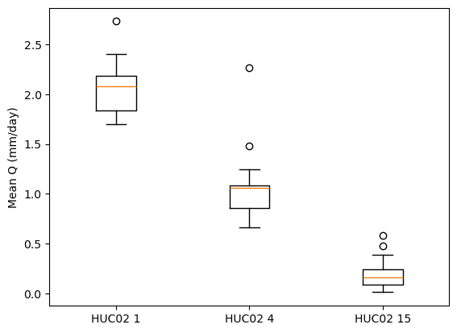

```python
huc1  = camels.loc[camels['huc_02'] == 1]
huc4  = camels.loc[camels['huc_02'] == 4]
huc15 = camels.loc[camels['huc_02'] == 15]

data = [huc1['q_mean'], huc4['q_mean'], huc15['q_mean']]

fig, ax = plt.subplots()
ax.boxplot(data)
ax.set_xticklabels(['HUC02 1', 'HUC02 4', 'HUC02 15'])
ax.set_ylabel('Mean Q (mm/day)')
```

```python
print(f'HUC 1 Aridity = {np.mean(huc1['aridity'])}')
print(f'HUC 4 Aridity = {np.mean(huc4['aridity'])}')
print(f'HUC 15 Aridity = {np.mean(huc15['aridity'])}')
```

```
HUC 1 Aridity = 0.5971574561700324
HUC 4 Aridity = 0.896107403436849
HUC 15 Aridity = 2.5168339277380367
```

Based on this boxplot, I would say hydrology between these regions is significantly different. HUC 1 (New England) and HUC 4 (Great Lakes) are far less arid than HUC 15 (Southern Basin and Range), which may partially explain why the mean daily discharge is so different.